# lesson_7

Caitlin Rivers

For our last episkills lesson this semester, we'll pull everything we've learned together by automatically generating a report. Many public health departments manually generate reports using Excel and Microsoft Word. As we've learned, computer code is much faster and less error prone (after checking it, of course) than manual analyses, especially for tasks you do repeatedly.

The people who read your reports don't want to sift through a bunch of ugly computer code to see your results. There are a few different ways to pull together analyses into something more sleek, automatically. The one shown below relies on just one extra line of code to hide your inputs, leaving only figures and output text.

When you look at the output from this fake report, you'll see some weird white spacing. That's only because I have long commented blocks for notes to the reader.. It won't appear if you implement your own version w/o comment blocks.

I will put my notes and asides in commented code blocks below, so they will be hidden when we generate our final report.

```python
# Our standard inputs
import pandas as pd
import numpy as np
import seaborn as sns
%pylab inline

# Use this to suppress any warnings so they don't show up on our report
import IPython.core.display as di
import warnings
warnings.filterwarnings('ignore')

# magic to interface with the files saved on your computer
import os
import glob

# This line will hide your code when you export to html
# thanks to Max Masnick for this one.
di.display_html('<script>jQuery(function() {if (jQuery("body.notebook_app").length == 0) { jQuery(".input_area").toggle(); jQuery(".prompt").toggle();}});</script>', raw=True)
```

```python
# Add formatted text (like that seen in the report title below) by using the markdown
# functions in IPython. To access a markdown cell, use the keyboard shortcut ctrl+m, m
# A quick Google search will turn up guidance for using markdown. It is *very* easy.
```

# (Fake) MERS Annual Report

```python
# Embed any image you want using the Image() function. This is useful for adding e.g. headers
# or logos to your reports.
```

[figure not shown]

```python
from IPython.display import Image
Image(filename='fake_logo.png')
```

```python
# Use the datetime package to automatically generate today's date
```

```python
print('Current as of: {}'.format(datetime.datetime.strftime(datetime.datetime.today(), '%b %d %Y')))
```

```
Current as of: Dec 17 2015
```

```python
# Put in any code you need to do your analyses, including functions.
# This code is pulled from episkills lessons 2, analyzing mers data.
```

```python
def process_file(df):
    df.age = df.age.convert_objects(convert_numeric=True)
    df.gender = df.gender.replace(['?', 'M?'], np.nan)

    labels = ['0-50', '51- 99']
    labels = ['0-9', '10-19', '20-29', '30-39', '40-49', '50-59', '60-69', '70-79', '80-89', '90+']
    df['age_group'] = pd.cut(df.age, range(0, 101, 10), right=False, labels=labels)

    df['onset'] = df.onset.dropna().apply(convert_date)

    return df
```

```python
def convert_date(x):
    try:
        x = datetime.datetime.strptime(x, '%m/%d/%Y')
    except:
        x = np.nan

    return x
```

```python
# The code below finds the most recent file with the extension .csv.
# Here I'm envisoning that you will regular get your data updates, save them,
# and run your code. This block will find the newest data file.
```

```python
try:
    fname = max(glob.iglob('*.csv'), key=os.path.getctime)
    raw_data = pd.read_csv(fname)
except:
    print('No file found.')
```

```python
### here we call on the functions we wrote above to process our data, e.g. replace bad values
```

```python
data = process_file(raw_data)
```

```python
# Example of a subheader
```

## Basic epidemiology

```python
#Automatically write sentences or even entire paragraphs using the print() function.
#You can also automatically insert words into your sentences using curly brackets: {} followed
#by .format(). In the example below, I update a sentence stating the number of cases
#in the previous reporting period.
```

```python
recent_cases = len(data[data.onset > '2015-01-01'])
print('This year there were {} new cases'.format(recent_cases))
```

```
This year there were 391 new cases
```

```python
# Figures will appear in our report. Here I put two figures side by side using the ncols argument
# in the plt.subplots() call. I also add titles to my figures.
# Finally, I put a text cell below with commentary (preferrably automatically generated!)
# on the figures.
```

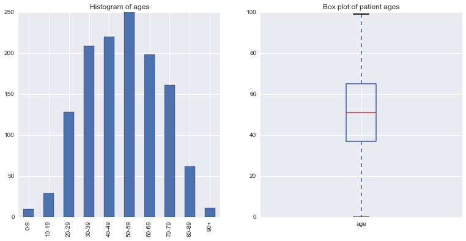

```python
fig, ax = plt.subplots(ncols=2, figsize=(13,6))
data.age_group.value_counts(sort=False).plot(kind='bar', ax=ax[0])
data.age.plot(kind='box', ax=ax[1])
ax[0].set_title('Histogram of ages')
ax[1].set_title('Box plot of patient ages');
```

```python
mean_male = data.age[data.gender == 'M'].median()
mean_female = data.age[data.gender == 'F'].median()
if mean_male > mean_female:
    direction = 'greater than'
elif mean_male == mean_female:
    direction = 'the same'
elif mean_male < mean_female:
    direction = 'less than'
print('The median age of male patients is {}, {} than the average age of female patients at {}.'\
      .format(mean_male, direction, mean_female))
```

```
The median age of male patients is 52.5, greater than than the average age of female patients at 50.0.
```

```python
#Another subheader with analysis...
```

## Geographic trends

```python
gender_grouped = data.pivot_table(index=['country'],
                           columns=['gender'],
                           values='age',
                           fill_value=np.nan)
```

```python
# ...to show that you can generate and display tables.
# I also add a table title below using markdown
```

**Average age of MERS patients by sex and country of diagnosis.**

```python
gender_grouped.T[['France', 'Iran', "KSA"]]
```

[output not shown]

```python
# Another figure
```

```python
gender_grouped['age_diff'] = gender_grouped['M'] - gender_grouped['F']
```

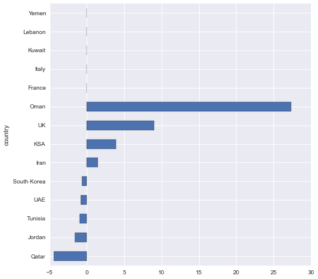

```python
fig, ax = plt.subplots(figsize=(8, 8))
gender_grouped['age_diff'].order().plot(kind='barh', ax=ax); #add a semicolon to stop matplotlib output
```

```python
# You could also add e.g. FOUO or logos or contact email at the end of the report.
```

```python
# When you are finished and ready to export, click File -> Download as -> HTML. If you
# don't see that option, you may need to update your installation. A download of an HTML
# will begin. From there, you can either distribute the finished html or you can print it to PDF.
# You could automate this export process, but it's a tad too much work for my taste so I'm not
# showing it here. If you generate a high volume of reports though, it would be worth looking into.s
```